# Task 5

```python
# Exploratory Data Analysis (EDA) on train.csv

# Step 1: Import Libraries

import pandas as pd
import numpy as np
import matplotlib.pyplot as plt
import seaborn as sns

# Display plots inline
%matplotlib inline

# Step 2: Load Data
# Load dataset
data = pd.read_csv("C:/Users/nikhi/OneDrive/Desktop/train.csv")
```

```python
Step 3
# Checking first few rows
data.head()
```

|  | PassengerId | Survived | Pclass | Name | Sex | Age | SibSp | Parch | Ticket | Fare | Cabin | Embarked |
| --- | --- | --- | --- | --- | --- | --- | --- | --- | --- | --- | --- | --- |
| 0 | 1 | 0 | 3 | Braund, Mr. Owen Harris | male | 22.0 | 1 | 0 | A/5 21171 | 7.2500 | NaN | S |
| 1 | 2 | 1 | 1 | Cumings, Mrs. John Bradley (Florence Briggs Th... | female | 38.0 | 1 | 0 | PC 17599 | 71.2833 | C85 | C |
| 2 | 3 | 1 | 3 | Heikkinen, Miss. Laina | female | 26.0 | 0 | 0 | STON/O2. 3101282 | 7.9250 | NaN | S |
| 3 | 4 | 1 | 1 | Futrelle, Mrs. Jacques Heath (Lily May Peel) | female | 35.0 | 1 | 0 | 113803 | 53.1000 | C123 | S |
| 4 | 5 | 0 | 3 | Allen, Mr. William Henry | male | 35.0 | 0 | 0 | 373450 | 8.0500 | NaN | S |

```python
# Basic info
data.info()
```

```
<class 'pandas.core.frame.DataFrame'>
RangeIndex: 891 entries, 0 to 890
Data columns (total 12 columns):
 #   Column       Non-Null Count  Dtype
---  ------       --------------  -----
 0   PassengerId  891 non-null    int64
 1   Survived     891 non-null    int64
 2   Pclass       891 non-null    int64
 3   Name         891 non-null    object
 4   Sex          891 non-null    object
 5   Age          714 non-null    float64
 6   SibSp        891 non-null    int64
 7   Parch        891 non-null    int64
 8   Ticket       891 non-null    object
 9   Fare         891 non-null    float64
 10  Cabin        204 non-null    object
 11  Embarked     889 non-null    object
dtypes: float64(2), int64(5), object(5)
memory usage: 83.7+ KB
```

```python
# Summary statistics
data.describe()
```

|  | PassengerId | Survived | Pclass | Age | SibSp | Parch | Fare |
| --- | --- | --- | --- | --- | --- | --- | --- |
| count | 891.000000 | 891.000000 | 891.000000 | 714.000000 | 891.000000 | 891.000000 | 891.000000 |
| mean | 446.000000 | 0.383838 | 2.308642 | 29.699118 | 0.523008 | 0.381594 | 32.204208 |
| std | 257.353842 | 0.486592 | 0.836071 | 14.526497 | 1.102743 | 0.806057 | 49.693429 |
| min | 1.000000 | 0.000000 | 1.000000 | 0.420000 | 0.000000 | 0.000000 | 0.000000 |
| 25% | 223.500000 | 0.000000 | 2.000000 | 20.125000 | 0.000000 | 0.000000 | 7.910400 |
| 50% | 446.000000 | 0.000000 | 3.000000 | 28.000000 | 0.000000 | 0.000000 | 14.454200 |
| 75% | 668.500000 | 1.000000 | 3.000000 | 38.000000 | 1.000000 | 0.000000 | 31.000000 |
| max | 891.000000 | 1.000000 | 3.000000 | 80.000000 | 8.000000 | 6.000000 | 512.329200 |

```python
# Checking for missing values
data.isnull().sum()
```

```
PassengerId      0
Survived         0
Pclass           0
Name             0
Sex              0
Age            177
SibSp            0
Parch            0
Ticket           0
Fare             0
Cabin          687
Embarked         2
dtype: int64
```

```python
# Checking for duplicate entries
data.duplicated().sum()
```

```
0
```

```python
# Step 4: Univariate Analysis
# Identify categorical and numerical columns
categorical_cols = data.select_dtypes(include=['object']).columns
numerical_cols = data.select_dtypes(include=['int64', 'float64']).columns
```

[figure not shown]

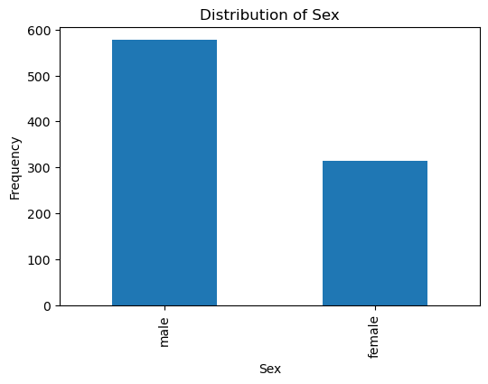

[figure not shown]

[figure not shown]

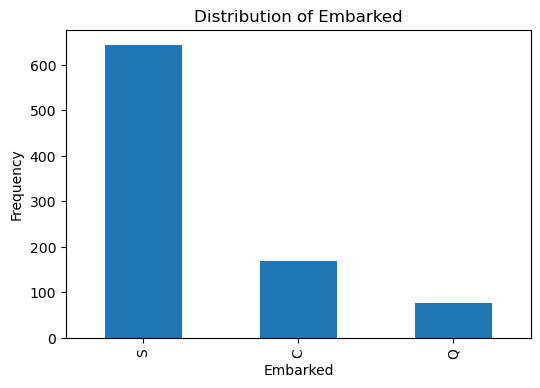

```python
# Plot categorical columns
for col in categorical_cols:
    plt.figure(figsize=(6,4))
    data[col].value_counts().plot(kind='bar')
    plt.title(f'Distribution of {col}')
    plt.xlabel(col)
    plt.ylabel('Frequency')
    plt.show()
```

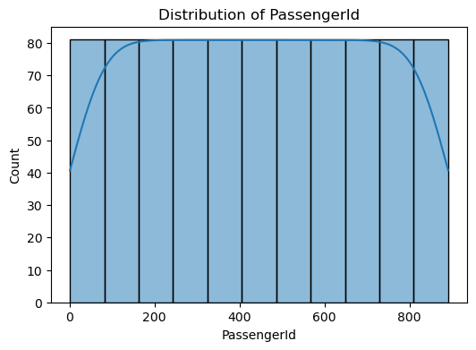

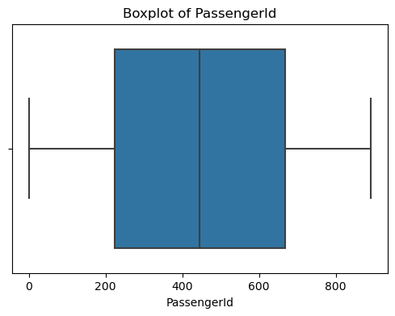

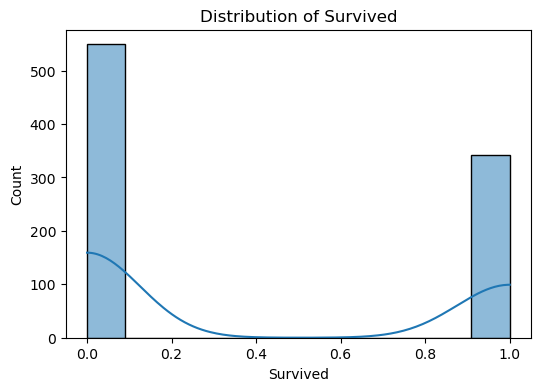

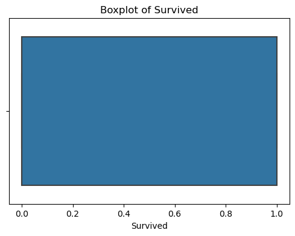

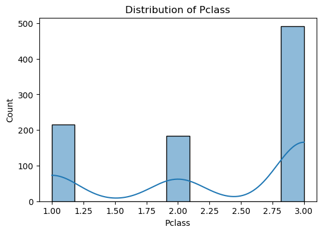

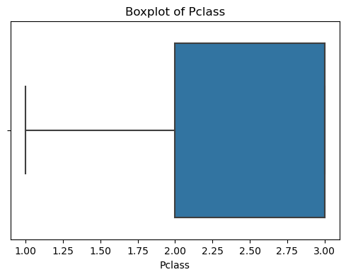

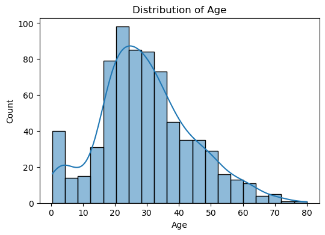

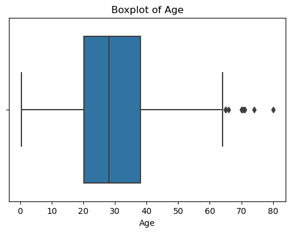

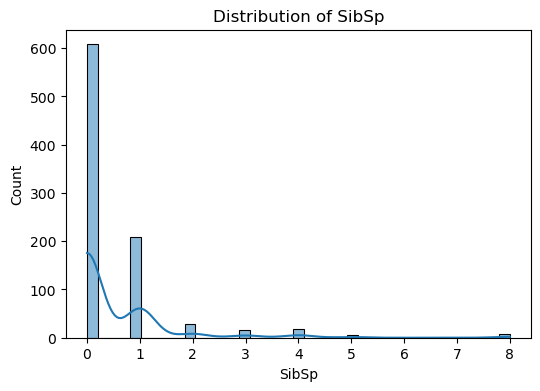

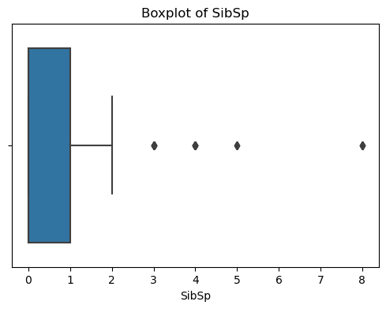

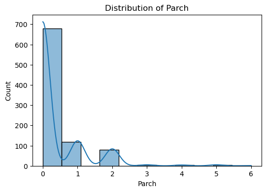

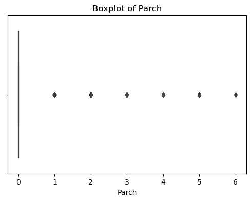

[2 more figures not shown]

```python
# Plot numerical columns
for col in numerical_cols:
    plt.figure(figsize=(6,4))
    sns.histplot(data[col], kde=True)
    plt.title(f'Distribution of {col}')
    plt.xlabel(col)
    plt.ylabel('Count')
    plt.show()

    plt.figure(figsize=(6,4))
    sns.boxplot(x=data[col])
    plt.title(f'Boxplot of {col}')
    plt.show()
```

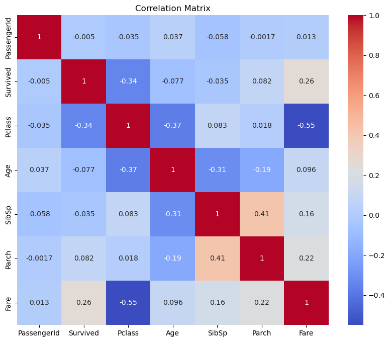

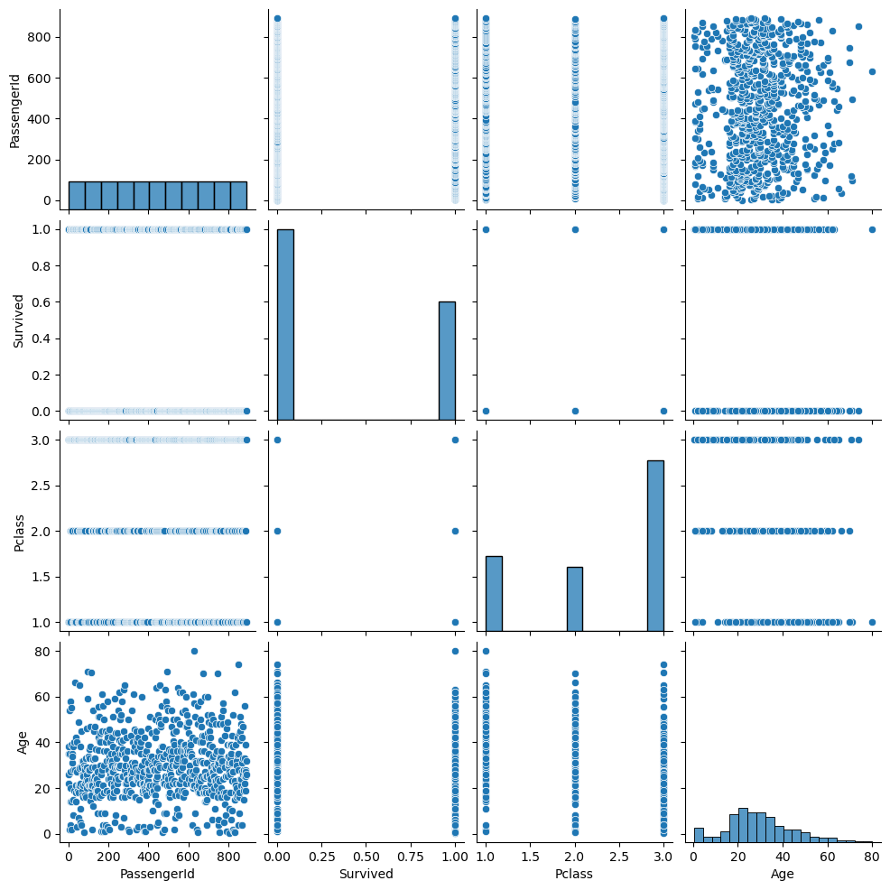

```python
# Step 5: Bivariate/Multivariate Analysis
# Correlation Matrix
plt.figure(figsize=(10,8))
sns.heatmap(data.corr(), annot=True, cmap='coolwarm')
plt.title('Correlation Matrix')
plt.show()

# Pairplot (limited to avoid heavy plots)
sns.pairplot(data[numerical_cols[:4]])  # Plot only first 4 numeric features
plt.show()
```

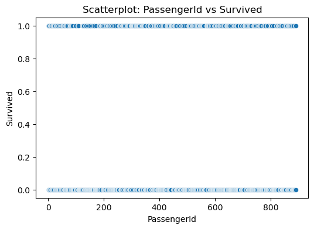

```python
if len(numerical_cols) >= 2:
    plt.figure(figsize=(6,4))
    sns.scatterplot(x=data[numerical_cols[0]], y=data[numerical_cols[1]])
    plt.title(f'Scatterplot: {numerical_cols[0]} vs {numerical_cols[1]}')
    plt.show()
```

# Observations for Each Visual

1. Categorical Columns (Bar Plots) Sex:

There are more males than females onboard.

Embarked:

Most passengers embarked from port S (Southampton).

Cabin:

Most entries are missing for Cabin information.

1. Numerical Columns (Histograms + Boxplots) Age:

Ages are mostly between 20 and 40 years.

Outliers exist (e.g., passengers aged 70–80).

Fare:

Most fares are low (under $100), but there are extreme high fares (outliers) up to $512.

SibSp (Siblings/Spouses aboard):

Most people traveled alone (0 siblings/spouses).

Parch (Parents/Children aboard):

Most passengers also had no parents or children with them.

Passenger Class (Pclass):

The largest group traveled in third class.

1. Correlation Matrix (Heatmap) Fare is negatively correlated with Pclass (lower class number → higher fare).

SibSp and Parch show some positive correlation (families tend to travel together).

Survived is somewhat correlated with Pclass and Fare (higher class and fare increased survival chances).

Age is spread similarly among survivors and non-survivors.

1. Scatterplot (PassengerId vs Survived) No visible relationship between PassengerId and Survival (as expected, ID is just an index).

# Summary of Findings